# Prioritizing Lead Free Water

## 0.1 Preliminaries

```r
library(rms)
library(Hmisc)
library(leaps)
library(MASS)
library(tidyverse)
```

# 1 Task 1: Data Source

I obtained my data from New York State Health Data. The data is collected from each public school and BOCES school in New York State. This database is updated daily as each school tests their water and receives the results. The schools must, according to legislation in New York, sample their water for lead contamination and report the results to parent, the Department of Health in New York, and local government officials. The schools report this data through a Department of Health electronic survey. This database was created on September 22, 2016 and last updated on February 23, 2018.

https://health.data.ny.gov/Health/Lead-Testing-in-School-Drinking-Water-Sampling-and/rkyy-fsv9/data

I also used data from Index Mundi on the percent of persons below poverty level by county in New York from 2009 to 2013. This data came from the U.S. Census Bureau, American Community Survey.

https://www.indexmundi.com/facts/united-states/quick-facts/new-york/percent-of-people-of-all-ages-in-poverty#table

# 2 Task 2: Load and Tidy the Data

```r
water <- read.csv("Lead_Testing.csv")
#water
water_work <- water %>%
  select(school, school.district, county, number.outlets, organization.type, lead.free.building, low.lead.outlets, high.lead.outlets) %>%
  filter(complete.cases(.))
poverty <- read.csv("NY_poverty.csv")
water_work1 <- merge(water_work, poverty, by= "county")
water_work1 <- water_work1 %>% filter(complete.cases(.))
set.seed(43)
water_work2 <- water_work1[sample(1:nrow(water_work), 1000,
    replace=FALSE),] %>% tbl_df
water_work2 <- water_work2 %>% filter(complete.cases(.))
#water_work2$lead.free.building<-ifelse(water_work2$lead.free.building=='Yes', 1,0)
```

I included only the variables I will potentially be using in my model and filtered it so to only contain the complete cases. I had 4,445 observations so I took a random subset of 1,000 observations. I merged two datasets by county so the percent of persons below the poverty level would be included in the original dataset.

# 3 Task 3: Listing of My Tibble

```r
water_work2
```

```
# A tibble: 994 x 9
   county  school      school.district     number.outlets organization.ty…
   <fct>   <fct>       <fct>                        <int> <fct>
 1 Nassau  ABBEY LANE… LEVITTOWN UNION FR…            129 Public School
 2 Ulster  M CLIFFORD… KINGSTON CITY SCHO…             83 Public School
 3 Bronx   X392        NYC DOE                         99 Public School
 4 Queens  Q869        NYC DOE                          6 Public School
 5 Kings   K400        NYC DOE                         78 Public School
 6 Niagara COLONIAL V… NIAGARA WHEATFIELD…            115 Public School
 7 Queens  Q184        NYC DOE                         97 Public School
 8 New Yo… M625        NYC DOE                        106 Public School
 9 Erie    CAYUGA HEI… DEPEW UNION FREE S…            109 Public School
10 Suffolk LONGWOOD M… LONGWOOD CENTRAL S…             81 Public School
# ... with 984 more rows, and 4 more variables: lead.free.building <fct>,
#   low.lead.outlets <int>, high.lead.outlets <int>, value <dbl>
```

Help, why are there still missing observations?

# 4 Task 4: Code Book

| Variable | Type | Details |
| --- | --- | --- |
| `school` | character | Name of school. |
| `school.district` | multi-categorical | School district in which the school is located. There are 337 school districts. BOCES schools are not listed as being in a district and are categorized as “BOCES No District Name” |
| `county` | multi-categorical | County in which the school is located. There are 61 counties. |
| `number.outlets` | quantitative | Total number of outlets required to be sampled for lead concentration. The maximum is 632 outlets and the minimum is 0. |
| `organization.type` | binary | Whether the school is public or BOCES. There are 970 public schools and 30 BOCES schools. |
| `lead.free.building` | binary | If there are any lead free building at the school. 982 schools do not have lead free buildings and 18 have one or more lead free buildings. |
| `low.lead.outlets` | quantitative | Number of outlets with a lead concentration equal to or below 15 ppb. The maximum is 572 outlets with low lead and the minimum is 0. |
| `high.lead.outlets` | quantitative | Number of outlets with a lead concentration greater than 15 ppb. The maximum is 290 outlets with high lead and the minimum is 0. |
| `value` | quantitative | Percent of persons below the poverty level. |

# 5 Task 5: My Subjects

Each subject is a single school in New York State. Each school submits data regarding their water outlets and lead levels through a survey made available online by the Department of Health. The data is updated by schools regularly when they have their water sampled and tested as per New York legislation. I have added the variable for percent of persons below the poverty level for each county. This data is gathered by U.S. Census Bureau.

# 6 Task 6: My Variables

The first column gives the name of the school. Next is the school district in which the school is located in New York. Thirdly, the county in New York State in which each school is located. The number of outlets is how many water outlets are required to be sampled. Organization type explains if the school is considered to be a public school or is part of the BOCES organization. Lead free buildings is binary and either the school has no buildings with lead-free water or it has one or more. Next are the number of outlets with low lead concentrations in the water and the number of outlets with high lead concentrations in the water. Low lead concentrations are equal or less than 15 ppb. High lead concentrations are classified as above 15 ppb. Finally is the percent of persons below the poverty level in 2009 to 2013 in the county in which the school is located.

# 7 Task 7: My Planned Linear Regression Model

My quantitative variable for my outcome is the number of water outlets with high lead concentrations. I plan to look at county, percent of persons below the poverty level in that county, number of outlets, and type of organization as my predictors.

# 8 Task 8: My Planned Logistic Regression Model

For my logistic regression I want to use the lead-free building variable as my binary outcome. I plan to use the same four predictors: county, percent of persons below the poverty level, number of outlets, and type of organization, as I did in my linear regression.

# 9 Task 9: Affirmation

- I am certain that it is completely appropriate for these data to be shared with anyone, without any conditions. There are no concerns about privacy or security.

# 10 Task 10 Analysis: Linear Regression

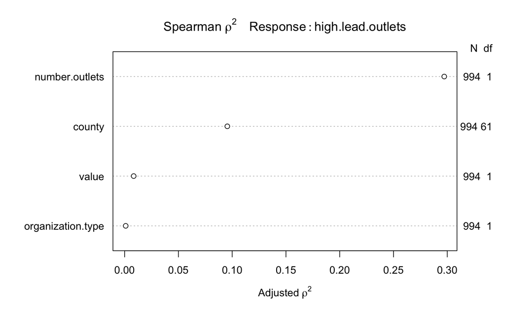

```r
plot(spearman2(high.lead.outlets ~ county + value + number.outlets + organization.type, data = water_work2))
```

How many degrees of freedom can you justify with a sample of 1000?

```r
bs_preds <- with(water_work2, cbind(county, value, number.outlets, organization.type))
bs_subs <- regsubsets(bs_preds,
                      y = water_work2$high.lead.outlets,
                      nvmax = 4)
bs_mods <- summary(bs_subs)
#bs_mods
#bs_mods$which
#t(bs_mods$which)
bs_winners <- tbl_df(bs_mods$which)
bs_winners$k <- 1:4
bs_winners$r2 <- bs_mods$rsq
bs_winners$adjr2 <- bs_mods$adjr2
bs_winners$cp <- bs_mods$cp
bs_winners$bic <- bs_mods$bic

temp.n <- nrow(water_work2)
temp.inputs <- 4

bs_mods$aic.corr <- temp.n*log(bs_mods$rss / temp.n) +
    2*(2:temp.inputs) +
    (2 * (2:temp.inputs) * ((2:temp.inputs)+1) /
         (temp.n - (2:temp.inputs) - 1))

bs_winners$aic.corr <- bs_mods$aic.corr
bs_winners
```

```
# A tibble: 4 x 11
  `(Intercept)` county value number.outlets organization.type     k    r2
  <lgl>         <lgl>  <lgl> <lgl>          <lgl>             <int> <dbl>
1 T             F      F     T              F                     1 0.359
2 T             F      T     T              F                     2 0.368
3 T             T      T     T              F                     3 0.370
4 T             T      T     T              T                     4 0.370
# ... with 4 more variables: adjr2 <dbl>, cp <dbl>, bic <dbl>,
#   aic.corr <dbl>
```

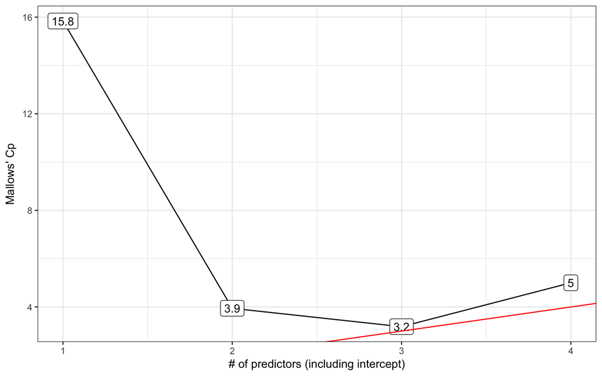

```r
Mallow_plot <- ggplot(bs_winners, aes(x = k, y = cp,
                            label = round(cp,1))) +
    geom_line() +
    geom_label() +
    geom_abline(intercept = 0, slope = 1,
                col = "red") +
    theme_bw() +
    scale_x_continuous(breaks = 1:4) +
    labs(x = "# of predictors (including intercept)",
         y = "Mallows' Cp")
Mallow_plot
```

R2 = model 4 Adj R2 = model 3 BIC = model 2 AIC = model 4 Cp = model 3

Of course this is all without giving more degrees of freedom to number.outlets and maybe county, so it will change.

```r
#validate(model?, method ="boot", B=40)
```

```r
#plot(nomogram(model?))
```

# 11 Task 11 Analysis: Logistic Regression

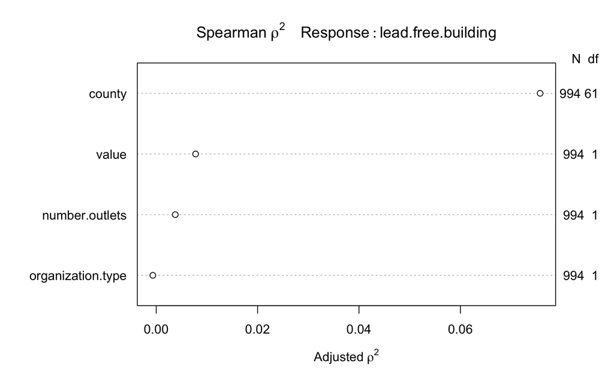

```r
plot(spearman2(lead.free.building ~ county + value + number.outlets + organization.type, data = water_work2))
```

High degrees of freedom on county. Probably no extra df on any others, right?

Laura Cremer

2018-03-08 11:47:56